# R Notebook

9. The ratio (-intercept/slope) estimates the point at which probability of survival is changing most rapidly. In toxicology this point is known as the LD50. Calculate this value** and compare it visually (add a line or something) with the fitted curve. Does it agree?

```r
library(MASS)
dose.p(z)
```

```
##              Dose        SE
## p = 0.5: 19.58683 0.1398026
```

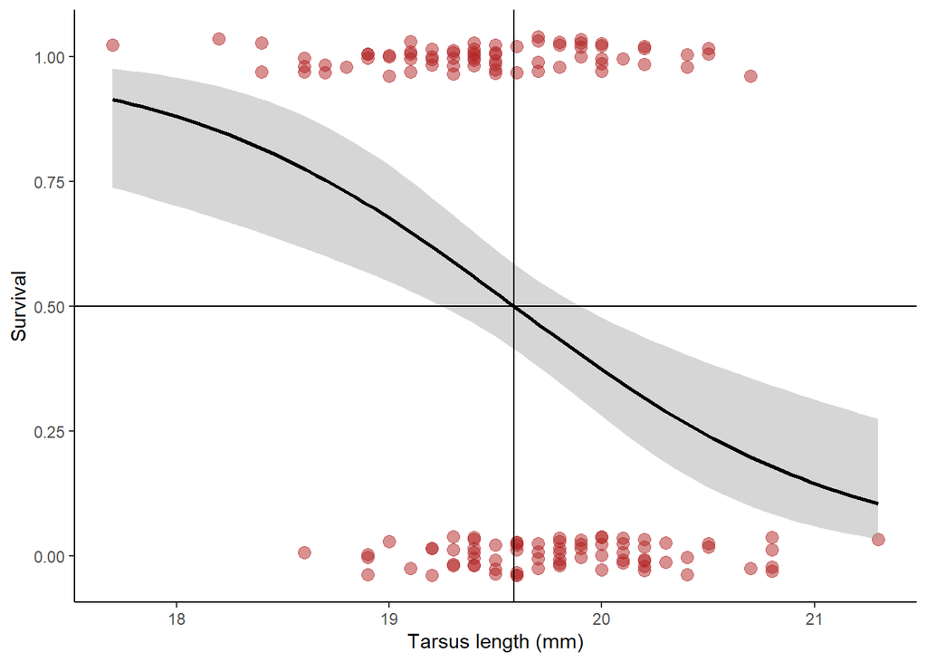

```r
ggplot(x, aes(tarsus, survival)) + geom_jitter(color = "firebrick", size = 3, height = 0.04, width = 0, alpha = 0.5)+
geom_smooth(method = "glm", method.args=list(family="binomial"), size = 1, col = "black", se = TRUE) + labs(x = "Tarsus length (mm)", y = "Survival") +  theme_classic()+geom_vline(xintercept = dose.p(z)[1])+geom_hline(yintercept = .5)
```

```r
#Yes, it agrees.The tarsus length is 19.58683 @ .50 survival.
```

10. Finally, the slope of the curve at a given value for the explanatory variable x is b * p(x) * ( 1 - p(x) ) for a binomial response, where b is the slope coefficient of the fitted logistic regression model and p(x) is the predicted probability of survival at that x.

Calculate the likelihood-based 95% confidence interval for the logistic regression coefficients.

```r
confint(z)
```

```
##                 2.5 %     97.5 %
## (Intercept) 12.035020 38.6162515
## tarsus      -1.970217 -0.6157285
```

11. The summary(z) output for the regression coefficients also includes “z values” and P-values. What caution would you take when interpreting these P-values? Use a more accurate method to test the null hypothesis of zero slope.

```r
library(car)
anova(z)
```

|  | Df | Deviance | Resid. Df | Resid. Dev |
| --- | --- | --- | --- | --- |
| NULL | NA | NA | 144 | 200.9506 |
| tarsus | 1 | 15.90787 | 143 | 185.0427 |

```r
Anova(z)
```

|  | LR Chisq | Df | Pr(>Chisq) |
| --- | --- | --- | --- |
| tarsus | 15.90787 | 1 | 6.650145e-05 |

```r
summary(z)
```

```
##
## Call:
## glm(formula = survival ~ tarsus, family = binomial(link = "logit"),
##     data = x)
##
## Deviance Residuals:
##     Min       1Q   Median       3Q      Max
## -1.7292  -1.0659  -0.6273   1.0794   1.8003
##
## Coefficients:
##             Estimate Std. Error z value Pr(>|z|)
## (Intercept)  24.6361     6.7455   3.652 0.000260 ***
## tarsus       -1.2578     0.3437  -3.659 0.000253 ***
## ---
## Signif. codes:  0 '***' 0.001 '**' 0.01 '*' 0.05 '.' 0.1 ' ' 1
##
## (Dispersion parameter for binomial family taken to be 1)
##
##     Null deviance: 200.95  on 144  degrees of freedom
## Residual deviance: 185.04  on 143  degrees of freedom
## AIC: 189.04
##
## Number of Fisher Scoring iterations: 4
```

```r
#
```

**Practice Data set 2**

**Crab satellites**

The horseshoe crab, Limulus polyphemus, has two alternative male reproductive morphs. Some males attach to females with a special appendage. The females bring these males with them when they crawl onto beaches to dig a nest and lay eggs, which the male then fertilizes. Other males are satellites, which are unattached to females but crowd around nesting pairs and obtain fertilization. What attributes of a female horseshoe crab determine the number of satellite males she attracts on the beaches?

The data here provide measurements of 173 female horseshoe crabs and record the number of satellites she attracted. The data were gathered by Brockman (1996. Satellite male groups in horseshoe crabs, Limulus polyphemus. Ethology 102:1-21) and were published by Agresti (2002, Categorical data analysis, 2nd ed. Wiley). The variables are female color, spine condition, carapace width (cm), mass (kg), and number of satellite males.

**step 1. Read and examine the data**

Read the data from the file. View the first few lines of data to make sure it was read correctly. Use the str() command to see the variables and groups.

```r
x <- read.csv("~/GitHub/satellites.csv",
          stringsAsFactors = FALSE)
head(x)
```

|  | color | spine | width.cm | nsatellites | mass.kg |
| --- | --- | --- | --- | --- | --- |
| 1 | medium | both.bad | 28.3 | 8 | 3.05 |
| 2 | dark-medium | both.bad | 22.5 | 0 | 1.55 |
| 3 | light-medium | good | 26.0 | 9 | 2.30 |
| 4 | dark-medium | both.bad | 24.8 | 0 | 2.10 |
| 5 | dark-medium | both.bad | 26.0 | 4 | 2.60 |
| 6 | medium | both.bad | 23.8 | 0 | 2.10 |

```r
str(x)
```

```
## 'data.frame':    173 obs. of  5 variables:
##  $ color      : chr  "medium" "dark-medium" "light-medium" "dark-medium" ...
##  $ spine      : chr  "both.bad" "both.bad" "good" "both.bad" ...
##  $ width.cm   : num  28.3 22.5 26 24.8 26 23.8 26.5 24.7 23.7 25.6 ...
##  $ nsatellites: int  8 0 9 0 4 0 0 0 0 0 ...
##  $ mass.kg    : num  3.05 1.55 2.3 2.1 2.6 2.1 2.35 1.9 1.95 2.15 ...
```

Plot the number of satellites against the width of the carapace, a measure of female body size. Fit a smooth curve to examine the trend.

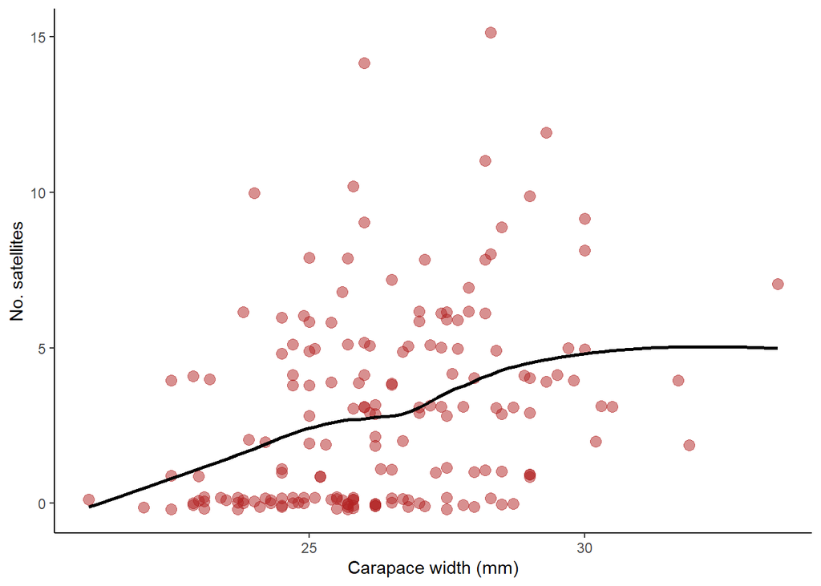

```r
ggplot(x, aes(width.cm, nsatellites)) +
    geom_jitter(color = "firebrick", size = 3, height = 0.2, width = 0, alpha = 0.5) +
  geom_smooth(method = "loess", size = 1, col = "black", se = FALSE) +
    labs(x = "Carapace width (mm)", y = "No. satellites") +
    theme_classic()
```

**step 2: Fit a generalized linear model**

Fit a generalized linear model to the relationship between number of satellite males and female carapace width. What type of variable is the number of satellites? What probability distribution might be appropriate to describe the error distribution around a model fit? What is the appropriate link function? Fit the model.

```r
z <- glm(nsatellites ~ width.cm, family = poisson(link = "log"), data = x)

#Discrete variable, Poisson distribution is appropriate and the appropriate link function is log link.
```

Visualize the model fit on the transformed scale (could try to do it with visreg(z, xvar = “width.cm”) and manually using ggplot?), including confidence bands. This plot reminds us that on the transformed scale, glm() is fitting a straight line relationship. (Don’t worry about the points – they aren’t the transformed data, but rather are “working values” for the response variable from the last iteration of model fitting, which glm() uses behind the scenes to fit the model on the transformed scale.)

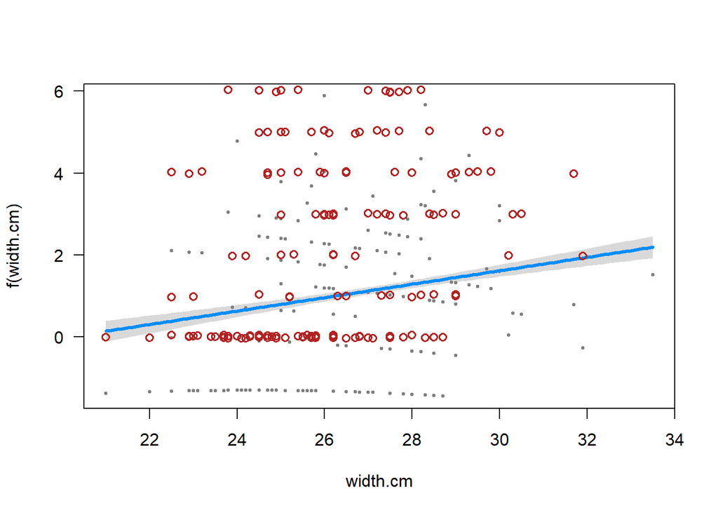

```r
visreg(z, xvar = "width.cm")
visreg(z, xvar = "width.cm", rug = FALSE); points(jitter(nsatellites, 0.2) ~ width.cm, data = x, pch = 1,
    col = "firebrick", lwd = 1.5)
```

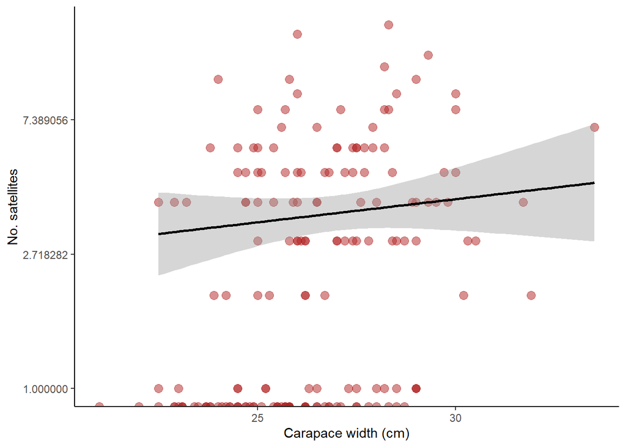

```r
ggplot(x, aes(width.cm, nsatellites)) +
    geom_point(color = "firebrick", size = 3, height = 0.2, width = 0, alpha = 0.5) +scale_y_continuous(trans="log")+
  geom_smooth(method = "lm", size = 1, col = "black", se = TRUE) +
    labs(x = "Carapace width (cm)", y = "No. satellites") +
    theme_classic()
```

Visualize the model fit on the original data scale. Note that it is curvilinear.

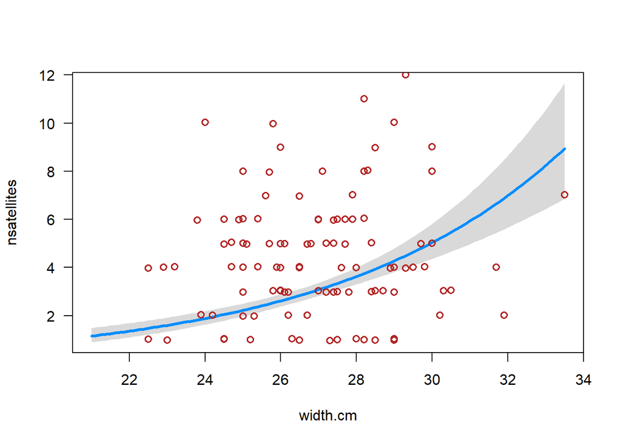

```r
visreg(z, xvar = "width.cm", scale = "response", rug = FALSE)
points(jitter(nsatellites, 0.2) ~ width.cm, data = x, pch = 1,
    col = "firebrick", lwd = 1.5)
```